# HW 5

Mikayla Norton

2023-03-01

# Problem 1

ISLR2 5.6: We continue to consider the use of a logistic regression model to predict the probability of default using income and balance on the Default data set. In particular, we will now compute estimates for the standard errors of the income and balance logistic regression coefficients in two different ways: (1) using the bootstrap, and (2) using the standard formula for computing the standard errors in the glm() function. Do not forget to set a random seed before beginning your analysis.

## Part A

Using the summary() and glm() functions, determine the estimated standard errors for the coefficients associated with income and balance in a multiple logistic regression model that uses both predictors.

```r
default_data <- ISLR2::Default
summary(glm(data = default_data, default ~ balance + income, family = binomial))
```

```
##
## Call:
## glm(formula = default ~ balance + income, family = binomial,
##     data = default_data)
##
## Deviance Residuals:
##     Min       1Q   Median       3Q      Max
## -2.4725  -0.1444  -0.0574  -0.0211   3.7245
##
## Coefficients:
##               Estimate Std. Error z value Pr(>|z|)
## (Intercept) -1.154e+01  4.348e-01 -26.545  < 2e-16 ***
## balance      5.647e-03  2.274e-04  24.836  < 2e-16 ***
## income       2.081e-05  4.985e-06   4.174 2.99e-05 ***
## ---
## Signif. codes:  0 '***' 0.001 '**' 0.01 '*' 0.05 '.' 0.1 ' ' 1
##
## (Dispersion parameter for binomial family taken to be 1)
##
##     Null deviance: 2920.6  on 9999  degrees of freedom
## Residual deviance: 1579.0  on 9997  degrees of freedom
## AIC: 1585
##
## Number of Fisher Scoring iterations: 8
```

## Part B

Write a function, boot.fn(),that takes as input the Default data set as well as an index of the observations, and that outputs the coefficient estimates for income and balance in the multiple logistic regression model.

```r
split_pct <- 0.7
n <- length(default_data$default)*split_pct # train size
row_samp <- sample(1:length(default_data$default), n, replace = FALSE)
boot.fn <- function(data=default_data, n=row_samp) {
  train <- default_data[row_samp,]
  boot.glm<-glm(data = train, default ~ income + balance, family = binomial)
  return(boot.glm$coefficients)
}
```

## Part C

```r
income.coeff <- rep(0, 100)
balance.coeff <- rep(0, 100)
#weight <- rep(0,length(diamonds$carat))
for(i in 1:100){
  coeffs<-boot.fn()
  income.coeff[i] <- coeffs[2]
  balance.coeff[i] <- coeffs[3]
}
cat("The 95% bootstrapped CI for the income coefficient is", quantile(income.coeff, c(0.025, 0.975)))
```

```
## The 95% bootstrapped CI for the income coefficient is 2.116022e-05 2.116022e-05
```

```r
cat("\n The 95% bootstrapped CI for the balance coefficient is", quantile(balance.coeff, c(0.025, 0.975)))
```

```
##
##  The 95% bootstrapped CI for the balance coefficient is 0.005434474 0.005434474
```

# Problem 2

ISLR2 8.4: This question relates to the plots in Figure 8.14.

## Part A

Sketch the tree corresponding to the partition of the predictor space illustrated in the left-hand panel of Figure 8.14. The num- bers inside the boxes indicate the mean of Y within each region.

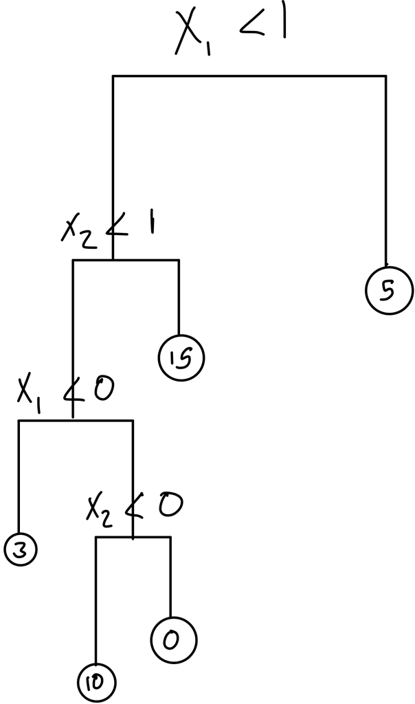

Part 2-A

## Part B

Create a diagram similar to the left-hand panel of Figure 8.14, using the tree illustrated in the right-hand panel of the same figure. You should divide up the predictor space into the correct regions, and indicate the mean for each region.

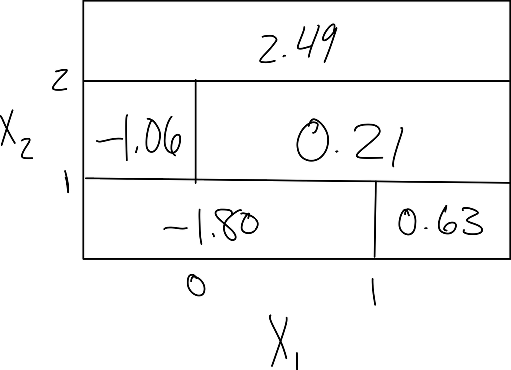

Part 2-B

# Problem 3

ISLR2 8.9: This problem involves the OJ data set which is part of the ISLR2 package.

```r
oj <- ISLR2::OJ
```

## Part A

Create a training set containing a random sample of 800 observations, and a test set containing the remaining observations.

```r
n <- 800 # train size
row_samp <- sample(1:length(oj$Purchase), n, replace = FALSE)
train <- oj[row_samp,]
test <- oj[-row_samp,]
```

## Part B

Fit a tree to the training data, with Purchase as the response and the other variables as predictors. Use the summary() function to produce summary statistics about the tree, and describe the results obtained. What is the training error rate? How many terminal nodes does the tree have?

```r
OJ_tree <- tree(Purchase ~ ., data = train)
summary(OJ_tree)
```

```
##
## Classification tree:
## tree(formula = Purchase ~ ., data = train)
## Variables actually used in tree construction:
## [1] "LoyalCH"       "SalePriceMM"   "PriceDiff"     "DiscCH"
## [5] "ListPriceDiff"
## Number of terminal nodes:  8
## Residual mean deviance:  0.7723 = 611.6 / 792
## Misclassification error rate: 0.1675 = 134 / 800
```

## Part C

Type in the name of the tree object in order to get a detailed text output. Pick one of the terminal nodes, and interpret the information displayed.

```r
OJ_tree
```

```
## node), split, n, deviance, yval, (yprob)
##       * denotes terminal node
##
##  1) root 800 1075.00 CH ( 0.60250 0.39750 )
##    2) LoyalCH < 0.482304 298  315.10 MM ( 0.22148 0.77852 )
##      4) LoyalCH < 0.051325 65   10.33 MM ( 0.01538 0.98462 ) *
##      5) LoyalCH > 0.051325 233  275.90 MM ( 0.27897 0.72103 )
##       10) SalePriceMM < 2.04 117  103.80 MM ( 0.16239 0.83761 ) *
##       11) SalePriceMM > 2.04 116  155.80 MM ( 0.39655 0.60345 ) *
##    3) LoyalCH > 0.482304 502  459.80 CH ( 0.82869 0.17131 )
##      6) LoyalCH < 0.753545 250  302.00 CH ( 0.70800 0.29200 )
##       12) PriceDiff < -0.165 35   39.90 MM ( 0.25714 0.74286 ) *
##       13) PriceDiff > -0.165 215  225.80 CH ( 0.78140 0.21860 )
##         26) DiscCH < 0.15 189  212.00 CH ( 0.75132 0.24868 )
##           52) ListPriceDiff < 0.16 31   42.94 MM ( 0.48387 0.51613 ) *
##           53) ListPriceDiff > 0.16 158  156.40 CH ( 0.80380 0.19620 ) *
##         27) DiscCH > 0.15 26    0.00 CH ( 1.00000 0.00000 ) *
##      7) LoyalCH > 0.753545 252  102.40 CH ( 0.94841 0.05159 ) *
```

## Part D

Create a plot of the tree, and interpret the results.

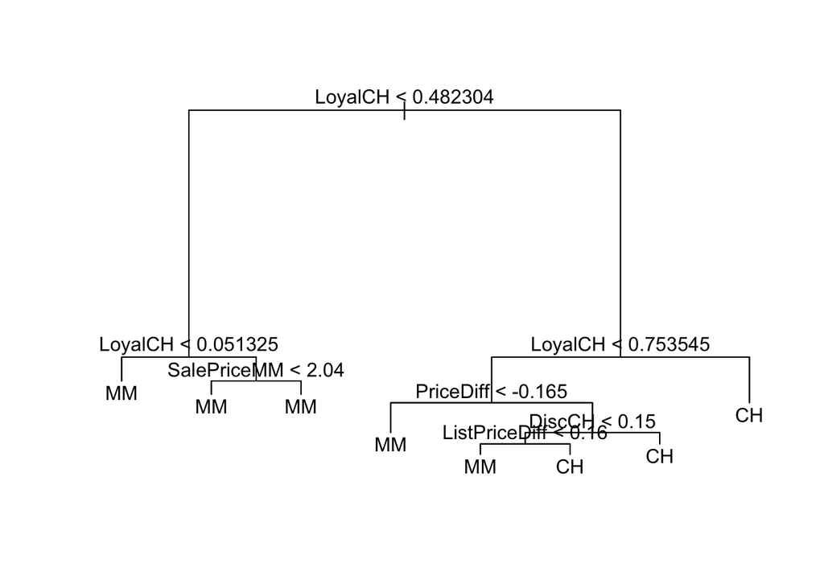

```r
plot(OJ_tree)
text(OJ_tree)
```

## Part E

Predict the response on the test data, and produce a confusion matrix comparing the test labels to the predicted test labels. What is the test error rate?

```r
tree_pred <- predict(OJ_tree, test, type = 'class')
confusionMatrix(tree_pred, test$Purchase)
```

```
## Confusion Matrix and Statistics
##
##           Reference
## Prediction  CH  MM
##         CH 137   9
##         MM  34  90
##
##                Accuracy : 0.8407
##                  95% CI : (0.7915, 0.8823)
##     No Information Rate : 0.6333
##     P-Value [Acc > NIR] : 4.314e-14
##
##                   Kappa : 0.6744
##
##  Mcnemar's Test P-Value : 0.0002522
##
##             Sensitivity : 0.8012
##             Specificity : 0.9091
##          Pos Pred Value : 0.9384
##          Neg Pred Value : 0.7258
##              Prevalence : 0.6333
##          Detection Rate : 0.5074
##    Detection Prevalence : 0.5407
##       Balanced Accuracy : 0.8551
##
##        'Positive' Class : CH
##
```

# Problem 4

For the OJ dataset create a (a) logistic regression model, (b) a Naïve Bayes model, and (c) a decision tree model, using PriceDiff and LoyalCH for each. Next, ensemble the predictions with a simple average. Create a confusion matrix for the ensembled model and compare the accuracies.

## Part A

Logistic regression model

```r
OJ_glm <- glm(data = train, Purchase ~ PriceDiff + LoyalCH, family = binomial)
test_pred <- predict(OJ_glm,test, type = "response")
confusionMatrix(as.factor(ifelse(test_pred < 0.5, 'CH', 'MM')), reference = as.factor(test$Purchase))$overall[1]
```

```
##  Accuracy
## 0.8407407
```

## Part B

Naïve Bayes model

```r
OJ_nbm <- naiveBayes(data = train, Purchase ~ PriceDiff + LoyalCH)
test_pred_nB <- predict(OJ_nbm, test)
confusionMatrix(as.factor(test_pred_nB), as.factor(test$Purchase))$overall[1]
```

```
##  Accuracy
## 0.8296296
```

## Part C

Decision tree model

```r
OJ_tree <- tree(Purchase ~ PriceDiff + LoyalCH, data = train)
tree_pred <- predict(OJ_tree, test, type = 'class')
confusionMatrix(tree_pred, test$Purchase)$overall[1]
```

```
##  Accuracy
## 0.8259259
```

## Part D

Ensembled Modeling

```r
glm_test <- ifelse(test_pred < 0.5, 0, 1)
nbm_test <- ifelse(test_pred_nB == "CH", 0, 1)
tree_test <- ifelse(tree_pred == "CH", 0, 1)
ensem_frac<-(glm_test+nbm_test+tree_test)/3
ensem_test<-ifelse(ensem_frac < 0.5, 'CH', 'MM')
confusionMatrix(as.factor(ensem_test), as.factor(test$Purchase))
```

```
## Confusion Matrix and Statistics
##
##           Reference
## Prediction  CH  MM
##         CH 147  24
##         MM  24  75
##
##                Accuracy : 0.8222
##                  95% CI : (0.7713, 0.8659)
##     No Information Rate : 0.6333
##     P-Value [Acc > NIR] : 8.433e-12
##
##                   Kappa : 0.6172
##
##  Mcnemar's Test P-Value : 1
##
##             Sensitivity : 0.8596
##             Specificity : 0.7576
##          Pos Pred Value : 0.8596
##          Neg Pred Value : 0.7576
##              Prevalence : 0.6333
##          Detection Rate : 0.5444
##    Detection Prevalence : 0.6333
##       Balanced Accuracy : 0.8086
##
##        'Positive' Class : CH
##
```

# Problem 5

Re-do the decision tree in 8.9 with bagging (1,000 bootstrapped samples of the train set). Compare the out-of-bag accuracy to the original decision tree.

```r
predicts <- matrix(nrow = length(test$Purchase), ncol = 0)
for(i in 1:1000){
  rows <- sample(1:length(train$Purchase), length(train$Purchase), replace = TRUE)
  samp <- OJ[rows,]
  OJ_trees <- tree(Purchase ~ ., data = samp)
  predicts = cbind(predicts, predict(OJ_trees, test)[,1])
}
ens <- rowMeans(predicts)

confusionMatrix(as.factor(ifelse(ens < 0.5, 'MM', 'CH')), reference = test$Purchase)
```

```
## Confusion Matrix and Statistics
##
##           Reference
## Prediction  CH  MM
##         CH 151  18
##         MM  20  81
##
##                Accuracy : 0.8593
##                  95% CI : (0.812, 0.8984)
##     No Information Rate : 0.6333
##     P-Value [Acc > NIR] : <2e-16
##
##                   Kappa : 0.6983
##
##  Mcnemar's Test P-Value : 0.8711
##
##             Sensitivity : 0.8830
##             Specificity : 0.8182
##          Pos Pred Value : 0.8935
##          Neg Pred Value : 0.8020
##              Prevalence : 0.6333
##          Detection Rate : 0.5593
##    Detection Prevalence : 0.6259
##       Balanced Accuracy : 0.8506
##
##        'Positive' Class : CH
##
```

```r
cat("Difference in Accuracy (bagging-original): ", confusionMatrix(as.factor(ifelse(ens < 0.5, 'MM', 'CH')), reference = test$Purchase)$overall[1] - confusionMatrix(tree_pred, test$Purchase)$overall[1])
```

[output not shown]